# Simple Explorartory Analysis

Jacinto

September 6, 2017

# Load Data

```r
# Contains all the properties with their home features for 2016. Note: Some 2017
# new properties don't have any data yet except for their parcelid's. Those data
# points should be populated when properties_2017.csv is available.
# 10/15/2017 started using properties_2017 instead of 2016 since they are the same
# with updated information for 2017 houses.
prop_2016 <- read_csv("data/properties_2017.csv",
                      # col_types, every 5 cols
                      col_types = paste0('iccid','dccdc',
                                         'idiii', 'iicii',
                                         'iilci','idiil',
                                         'llccc','ccccc',
                                         'dcici','iidil',
                                         'ddidd','cic'))

# Contains the training set with transactions from 1/1/2016 to 12/31/2016
train_2016 <- read_csv("data/train_2016_v2.csv",
                       col_types = 'cnD')

train_2017 <- read_csv("data/train_2017.csv",
                       col_types = 'cnD')
# Contains the a sample submission and also the test parcelids
# Asked to predict 6 time points: 201610, 201611, 201612, 201710, 201711, 201712
sample_sub <- read_csv("data/sample_submission.csv")
sample_sub_dates <- names(sample_sub)[-1]
sample_sub <- sample_sub[1]
```

```r
# Check if there is any problems reading the data into R
problems(prop_2016)
```

```
## # tibble [0 x 4]
## # ... with 4 variables: row <int>, col <int>, expected <chr>, actual <chr>
```

```r
problems(train_2016)
```

```
## # tibble [0 x 4]
## # ... with 4 variables: row <int>, col <int>, expected <chr>, actual <chr>
```

```r
problems(sample_sub)
```

```
## # tibble [0 x 4]
## # ... with 4 variables: row <int>, col <int>, expected <chr>, actual <chr>
```

## Convert to correct column types and relabeling factors

```r
# double to integer
tmp_col <- c('bedroomcnt','calculatedfinishedsquarefeet', 'roomcnt', 'yearbuilt')
for (c in tmp_col){
  prop_2016[[c]] <- as.integer(prop_2016[[c]])
}

# Change taxdelinquencyflag from Y to logic true
prop_2016$taxdelinquencyflag <- prop_2016$taxdelinquencyflag == 'Y'

# Read labels from data dictionary and use it to change factor's labels
data_dict <- loadWorkbook("data/zillow_data_dictionary.xlsx")

tmp_col <- c("PropertyLandUseTypeID", "HeatingOrSystemTypeID",
             "StoryTypeID", "AirConditioningTypeID",
             "ArchitecturalStyleTypeID","TypeConstructionTypeID")

for(c in tmp_col){
  tmp_sheet <- readWorksheet(data_dict, c)
  c <- tolower(c)
  prop_2016[[c]] <- factor(prop_2016[[c]],
                           levels = tmp_sheet[[1]],
                           labels = tmp_sheet[[2]])
}
rm(data_dict, tmp_sheet, tmp_col)

# Shorten description from data_dict
prop_2016$buildingclasstypeid <- factor(prop_2016$buildingclasstypeid,
                                        levels = 1:5,
                                        labels = c("fireproofed steel",
                                                   "fireproofed concrete",
                                                   "firedproofed exterior",
                                                   "wood plus steel frame",
                                                   "other"))

# External Labels
# Federal information processing standard code
prop_2016$fips <- factor(prop_2016$fips,
                         levels = c('06037', '06059', '06111'),
                         labels = c('Los Angeles', 'Orange', 'Ventura'))

# buildingqualitytypeid
# overall assessment of condition of the building from best(lowest) to worst(higest)
prop_2016$buildingqualitytypeid <- factor(prop_2016$buildingqualitytypeid,
                                          levels = as.character(1:12),
                                          labels = c('1best','2','3','4','5',
                                                     '6mid','7','8','9','10',
                                                     '11','12worst'),
                                          ordered = TRUE)

# the rest of the character columns are kept as if because:
# too many levels, lack of information, save as if for later use.
# rawcensustractandblock = 100,300
# regionidneighborhood = 529
# regionidzip = 406
# censustractandblock = 96772
```

```r
# Scaling down the longitude and latitude
prop_2016$longitude <- prop_2016$longitude/1000000
prop_2016$latitude <- prop_2016$latitude/1000000
```

# Table’s characteristics

```r
tmp_df <- list(prop_2016, train_2016, sample_sub)
data.frame(table = c("prop_2016", "train_2016", "sample_sub"),
           num_of_rows = sapply(tmp_df,
                                function(x) scales::comma(nrow(x))),
           num_of_col = sapply(tmp_df, ncol),
           # Faction of table is complete
           comp_case_frac = sapply(tmp_df, function(x) sum(complete.cases(x))/nrow(x)),
           memory_mb = sapply(tmp_df,
                              function(x) format(object.size(x), unit = "MB")),
           stringsAsFactors = FALSE)
```

```
##        table num_of_rows num_of_col comp_case_frac memory_mb
## 1  prop_2016   2,985,217         58              0  877.9 Mb
## 2 train_2016      90,275          3              1    6.9 Mb
## 3 sample_sub   2,985,217          1              1   11.4 Mb
```

```r
rm(tmp_df)
```

# From this point on, looking only at houses in training_2016

Because it is the only data that is being used in the model so looking at the rest would be kind of cheating.

```r
# Return only properties in train_2016
prop_train <- prop_2016 %>% filter(parcelid %in% unique(train_2016$parcelid))
# Properties that were sold more than once in the year 2016
sold_multi <- train_2016$parcelid %>% table %>% (function(x) x[x > 1])
# Most were sold twice while there is one that was sold thrice
table(sold_multi)
```

```
## sold_multi
##   2   3
## 123   1
```

```r
# The special property sold three times
sold_multi[sold_multi > 2] %>% names()
```

```
## [1] "11842707"
```

```r
rm(sold_multi)
```

# Summary

```r
summary(prop_train)
```

```
##     parcelid           airconditioningtypeid  architecturalstyletypeid
##  Min.   : 10711738   Central      :26722     Contemporary :  220
##  1st Qu.: 11559700   Yes          : 1828     Conventional :   16
##  Median : 12547436   None         :  215     Bungalow     :   11
##  Mean   : 12984883   Wall Unit    :   63     Ranch/Rambler:    8
##  3rd Qu.: 14227573   Refrigeration:   55     Cape Cod     :    4
##  Max.   :162960842   (Other)      :    1     (Other)      :    1
##                      NA's         :61266     NA's         :89890
##   basementsqft     bathroomcnt       bedroomcnt
##  Min.   : 100.0   Min.   : 0.000   Min.   : 0.000
##  1st Qu.: 407.5   1st Qu.: 2.000   1st Qu.: 2.000
##  Median : 616.0   Median : 2.000   Median : 3.000
##  Mean   : 713.6   Mean   : 2.294   Mean   : 3.046
##  3rd Qu.: 872.0   3rd Qu.: 3.000   3rd Qu.: 4.000
##  Max.   :1555.0   Max.   :20.000   Max.   :16.000
##  NA's   :90107    NA's   :17       NA's   :17
##             buildingclasstypeid buildingqualitytypeid calculatedbathnbr
##  fireproofed steel    :    0    8      :16926         Min.   : 1.000
##  fireproofed concrete :    0    6mid   :15583         1st Qu.: 2.000
##  firedproofed exterior:    0    4      :10952         Median : 2.000
##  wood plus steel frame:   17    7      : 6849         Mean   : 2.316
##  other                :    0    9      : 2615         3rd Qu.: 3.000
##  NA's                 :90133    (Other): 4426         Max.   :20.000
##                                 NA's   :32799         NA's   :863
##   decktypeid        finishedfloor1squarefeet calculatedfinishedsquarefeet
##  Length:90150       Min.   :  44             Min.   :    2
##  Class :character   1st Qu.: 938             1st Qu.: 1186
##  Mode  :character   Median :1245             Median : 1543
##                     Mean   :1348             Mean   : 1778
##                     3rd Qu.:1614             3rd Qu.: 2101
##                     Max.   :7625             Max.   :22741
##                     NA's   :83211            NA's   :384
##  finishedsquarefeet12 finishedsquarefeet13 finishedsquarefeet15
##  Min.   :    2        Min.   :1056         Min.   :  526
##  1st Qu.: 1173        1st Qu.:1392         1st Qu.: 1640
##  Median : 1520        Median :1440         Median : 2103
##  Mean   : 1751        Mean   :1405         Mean   : 2376
##  3rd Qu.: 2063        3rd Qu.:1440         3rd Qu.: 2862
##  Max.   :20013        Max.   :1584         Max.   :22741
##  NA's   :4369         NA's   :90117        NA's   :86593
```

[output cut: 97 more lines]

```
##  Min.   :     282      Min.   :    49.2   Mode:logical
##  1st Qu.:   97636      1st Qu.:  2894.7   TRUE:1774
##  Median :  214286      Median :  4560.4   NA's:88376
##  Mean   :  303250      Mean   :  6001.0
##  3rd Qu.:  372991      3rd Qu.:  6927.0
##  Max.   :24873625      Max.   :321936.1
##  NA's   :18            NA's   :28
##  taxdelinquencyyear censustractandblock
##  Min.   : 6.0       Length:90150
##  1st Qu.:13.0       Class :character
##  Median :14.0       Mode  :character
##  Mean   :13.4
##  3rd Qu.:15.0
##  Max.   :99.0
##  NA's   :88376
```

# Looking at Missing Values

## Overview

```r
prop_miss <- aggr(prop_train, plot = F)

# Calculate and sort the percentage of missing data per feature
miss <- prop_miss$missings %>%
  mutate(Percent = round((Count/nrow(prop_miss$x))*100, digits = 3)) %>%
  arrange(desc(Percent))
miss
```

```
##                        Variable Count Percent
## 1           buildingclasstypeid 90133  99.981
## 2          finishedsquarefeet13 90117  99.963
## 3                  basementsqft 90107  99.952
## 4                   storytypeid 90107  99.952
## 5            yardbuildingsqft26 90055  99.895
## 6                 fireplaceflag 89930  99.756
## 7      architecturalstyletypeid 89890  99.712
## 8        typeconstructiontypeid 89852  99.669
## 9           finishedsquarefeet6 89755  99.562
## 10                 pooltypeid10 89591  99.380
## 11                   decktypeid 89478  99.255
## 12                  poolsizesum 89184  98.928
## 13                  pooltypeid2 88932  98.649
## 14           taxdelinquencyflag 88376  98.032
```

[output cut: 44 more lines]

## Most Common Pattern

Only looking at a subset of the patterns because there are 1194.

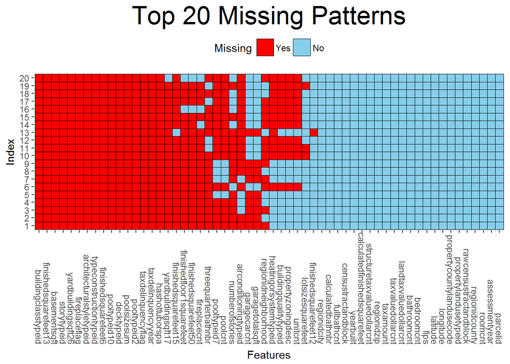

```r
# Select only top # most common missing pattern
top = 20

# Convert matrix to data.frame
miss_pattern <- as.data.frame(prop_miss$tabcomb)
# Extract column names and assign to data.frame
names(miss_pattern) <- colnames(prop_miss$x)
# Order the columns from most to least amount missing
miss_pattern <- miss_pattern[, order(prop_miss$missings$Count, decreasing = T)]
# Order the rows from most to least common pattern by percent
miss_pattern_order <- order(prop_miss$percent, decreasing = T)
miss_pattern <- miss_pattern[miss_pattern_order, ]
# Only keeping the top# pattern
miss_pattern <- miss_pattern[1:top,]
# Index rows
miss_pattern$index <- 1:nrow(miss_pattern)
# Format by gathering all columns but index
miss_pattern %<>% gather(key = 'feature', value = 'missing', -index)

ggplot(miss_pattern, aes(x = fct_inorder(feature),
                         y = factor(index),
                         fill = factor(missing,
                                       levels = c(1,0),
                                       labels = c("Yes", "No")))) +
  geom_tile(col = 'black') +
  scale_fill_manual(values = c('No' = 'skyblue', 'Yes' = 'red')) +
  labs(x = 'Features', y = 'Index',
       title = paste('Top', top, 'Missing Patterns'),
       fill = 'Missing') +
  theme(axis.text.x = element_text(angle = -90, hjust = 1, vjust = 0.5),
        plot.title = element_text(size = 25, hjust = 0.5),
        legend.position = 'top')
```

There does not seem to be an obvious pattern.

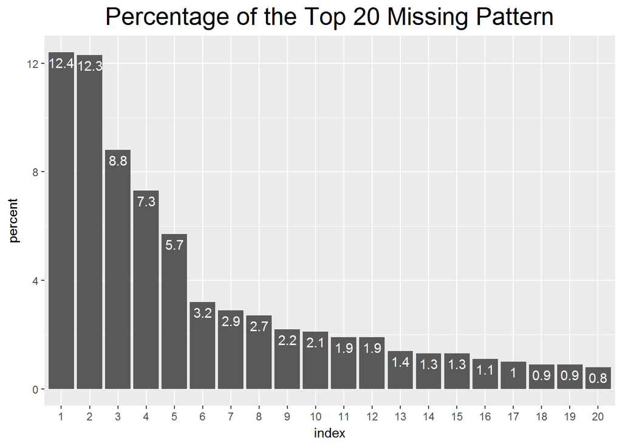

```r
data.frame(index = as.factor(1:top),
           percent = round(prop_miss$percent[miss_pattern_order[1:top]], 1)) %>%
  ggplot(aes(x = index, y = percent)) +
  geom_bar(stat = 'identity') +
  geom_text(aes(label = percent), vjust = 1.5, color = 'white') +
  labs(title = paste("Percentage of the Top", top, "Missing Pattern")) +
  theme(plot.title = element_text(size = 20, hjust = 0.5))
```

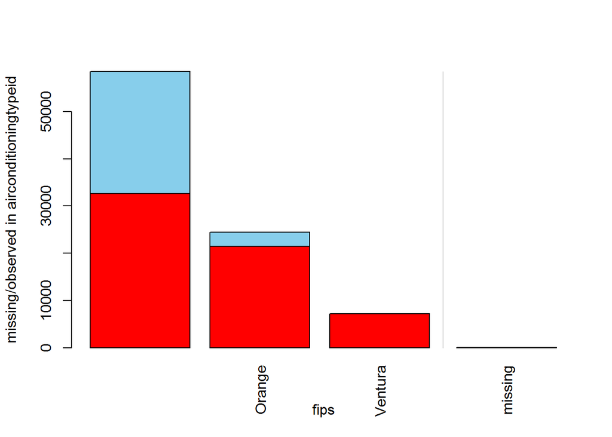

```r
barMiss(as.data.frame(prop_train[,c('fips', 'airconditioningtypeid')]))
```

```r
cn_filter <- miss %>% filter(Percent < 50, Percent > 5) %$% Variable

# prop_train %>% select(one_of(c('airconditioningtypeid', 'fips'))) %>%
#   as.data.frame %>% LittleMCAR()
```

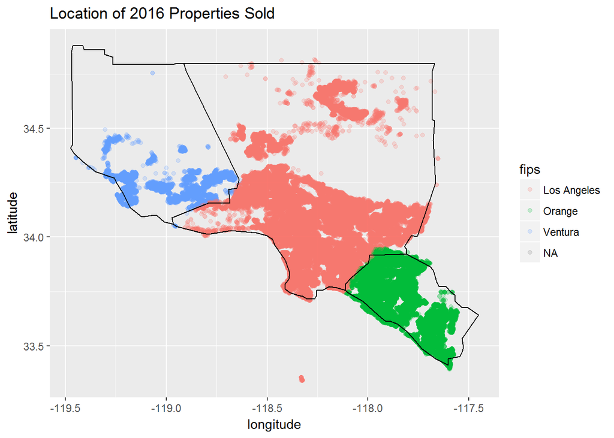

```r
map_loc <- map_data('county', region = 'california') %>%
  filter(subregion %in% c('los angeles', 'orange', 'ventura')) %>%
  # Adjustment to match the housing location better on map
  mutate(lat = lat - 0.02, long = long - 0.02)


ggplot(prop_train, aes(x = longitude, y = latitude, color = fips)) +
  geom_point(alpha = 0.2) +
  geom_polygon(data = map_loc, aes(x = long, y = lat, group = group),
               fill = NA, color = 'black') +
  labs(title = "Location of 2016 Properties Sold")
```

The few dots on the bottom of the map is Santa Catalina Island which is part of Los Angeles County.

## Airconiditioningtypeid

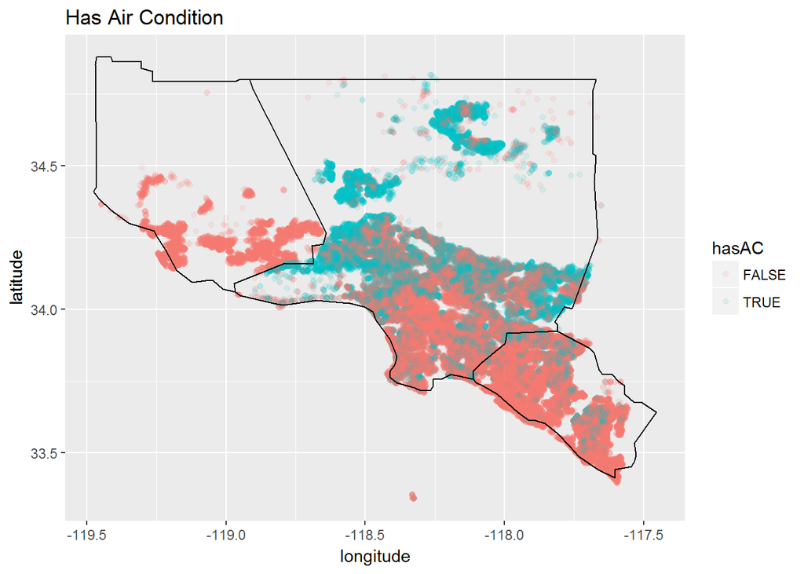

```r
no_ac <- prop_train %>%
  select(longitude, latitude, airconditioningtypeid) %>%
  mutate(hasAC = !(airconditioningtypeid %in% c(NA, 'None')))

ggplot(no_ac, aes(x = longitude, y = latitude, color = hasAC)) +
  geom_point(alpha = 0.1)+
  geom_polygon(data = map_loc, aes(x = long, y = lat, group = group),
               fill = NA, color = 'black') +
  labs(title = "Has Air Condition")
```

It looks like NA is most likely properties without AC.

## buildingclasstypeid, buildingqualitytypeid

```r
table(prop_train$buildingclasstypeid, useNA = 'always')
```

```
##
##     fireproofed steel  fireproofed concrete firedproofed exterior
##                     0                     0                     0
## wood plus steel frame                 other                  <NA>
##                    17                     0                 90133
```

Buildingclasstypeid doesn’t seem to contain any information

```r
prop_train$buildingqualitytypeid %>% table(useNA = 'always')
```

```
## .
##   1best       2       3       4       5    6mid       7       8       9
##      36       4     358   10952    2434   15583    6849   16926    2615
##      10      11 12worst    <NA>
##     357    1104     133   32799
```

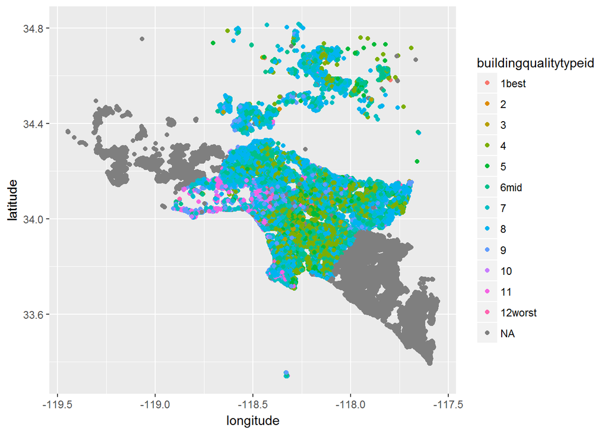

```r
prop_train %>%
  ggplot(aes(x = longitude, y = latitude, color = buildingqualitytypeid)) +
  geom_point()
```

It looks there is some spatial relationship between buildingqualitytypeid with the property’s location. This is reasonable. If two house are in a bad neighborhood, they are likely to be both in poor condition.  
Another pattern is that Orange and Ventura are not ranked.

I can use mice to impute the rank for those in Los Angeles. Then I will add NA as 13 and add a feature hasqualityflag.

## finishedsquarefeet13, finishedsquarefeet6, finishedsquarefeet15, finishedsquarefeet50, finishedsquarefeet12, finishedfloor1squarefeet, calculatedfinishedsquarefeet

```r
prop_train %>%
  select(finishedsquarefeet13, finishedsquarefeet6, finishedsquarefeet15,
         finishedsquarefeet50, finishedfloor1squarefeet,
         finishedsquarefeet12, calculatedfinishedsquarefeet) %>%
  summary()
```

```
##  finishedsquarefeet13 finishedsquarefeet6 finishedsquarefeet15
##  Min.   :1056         Min.   : 257        Min.   :  526
##  1st Qu.:1392         1st Qu.:1103        1st Qu.: 1640
##  Median :1440         Median :2052        Median : 2103
##  Mean   :1405         Mean   :2308        Mean   : 2376
##  3rd Qu.:1440         3rd Qu.:3431        3rd Qu.: 2862
##  Max.   :1584         Max.   :7224        Max.   :22741
##  NA's   :90117        NA's   :89755       NA's   :86593
##  finishedsquarefeet50 finishedfloor1squarefeet finishedsquarefeet12
##  Min.   :   44.0      Min.   :  44             Min.   :    2
##  1st Qu.:  938.5      1st Qu.: 938             1st Qu.: 1173
##  Median : 1250.0      Median :1245             Median : 1520
##  Mean   : 1364.6      Mean   :1348             Mean   : 1751
##  3rd Qu.: 1623.0      3rd Qu.:1614             3rd Qu.: 2063
##  Max.   :14508.0      Max.   :7625             Max.   :20013
##  NA's   :83211        NA's   :83211            NA's   :4369
##  calculatedfinishedsquarefeet
##  Min.   :    2
##  1st Qu.: 1186
##  Median : 1543
##  Mean   : 1778
##  3rd Qu.: 2101
##  Max.   :22741
##  NA's   :384
```

it seems like **finishedfloor1squarefeet is the same as finishedsquarefeet50** because they have the exact same definition. However the max are different.

```r
tmp <- with(prop_train, which(finishedfloor1squarefeet != finishedsquarefeet50))
prop_train[tmp, c('finishedsquarefeet50','finishedfloor1squarefeet')] %>%
  mutate(diff = finishedsquarefeet50 - finishedfloor1squarefeet,
         ratio_50_to_floor = finishedsquarefeet50/finishedfloor1squarefeet) %>%
  summary()
```

```
##  finishedsquarefeet50 finishedfloor1squarefeet      diff
##  Min.   :  828        Min.   :  58.0           Min.   :  765
##  1st Qu.: 2172        1st Qu.: 926.5           1st Qu.: 1173
##  Median : 3010        Median :1335.0           Median : 1694
##  Mean   : 3613        Mean   :1546.7           Mean   : 2067
##  3rd Qu.: 4572        3rd Qu.:2108.0           3rd Qu.: 2445
##  Max.   :14508        Max.   :3816.0           Max.   :10816
##  ratio_50_to_floor
##  Min.   : 2.005
##  1st Qu.: 2.063
##  Median : 2.201
##  Mean   : 2.574
##  3rd Qu.: 2.427
##  Max.   :14.276
```

Since there is only 32 entry that are different from each other and finishedsquarefeet50 is generally 2 fold larger than finishedfloor1squarefeet which suggest a structure pattern. I will just throw out finishedfloorsquarefeet.  
it seems like **calculatedfinishedsquarefeet is the same as finishedsquarefeet15** because both are defined as total area.

```r
with(prop_train, which(calculatedfinishedsquarefeet != finishedsquarefeet15))
```

```
## integer(0)
```

This shows that they have the same values when neither are NA. finishedsquarefeet15 is to be thrown away because majority of it is missing.

```r
# Check to see if calculatedfinishedsquarefeet is the sum of the
# finishedsquarefeet features
# Get the index of each finishedsquarefeet that is not NA
tmp13 <- with(prop_train, which(!is.na(finishedsquarefeet13)))
tmp6 <- with(prop_train, which(!is.na(finishedsquarefeet6)))
tmp50 <- with(prop_train, which(!is.na(finishedsquarefeet50)))
tmp12 <- with(prop_train, which(!is.na(finishedsquarefeet12)))
# Display a few from each
prop_train[c(tmp13[1:3], tmp6[1:3], tmp50[1:3], tmp12[1:3]),
          c('calculatedfinishedsquarefeet',
          'finishedsquarefeet13',
          'finishedsquarefeet6',
          'finishedsquarefeet50',
          'finishedsquarefeet12')]
```

```
## # A tibble: 12 x 5
##    calculatedfinishedsquarefeet finishedsquarefeet13 finishedsquarefeet6
##                           <int>                <int>               <int>
##  1                         1440                 1440                  NA
##  2                         1416                 1416                  NA
##  3                         1344                 1344                  NA
##  4                          800                   NA                 800
##  5                         1102                   NA                1102
##  6                         1457                   NA                1457
##  7                         1264                   NA                  NA
##  8                          777                   NA                  NA
##  9                         1101                   NA                  NA
## 10                         1264                   NA                  NA
## 11                          777                   NA                  NA
## 12                         1101                   NA                  NA
## # ... with 2 more variables: finishedsquarefeet50 <int>,
## #   finishedsquarefeet12 <int>
```

```r
# Find entry with more than two finishedsquarefeet that are not NA
# There are no overlap for 6 and 13 with 12.
intersect(tmp13, tmp12)
```

```
## integer(0)
```

```r
intersect(tmp6, tmp12)
```

```
## integer(0)
```

```r
intersect(tmp13, tmp6)
```

```
## integer(0)
```

```r
intersect(tmp50, c(tmp13, tmp6))
```

```
## integer(0)
```

```r
# Only 50 has overlap with 12
intersect(tmp50, tmp12) %>% length()
```

```
## [1] 6934
```

```r
# Are there any NA for calculatedfinishedsquarefeet where
# finishedsquarefeet aren't
intersect(which(is.na(prop_train$calculatedfinishedsquarefeet)),
          c(tmp6, tmp13, tmp12))
```

```
## integer(0)
```

There are none to help fill in the NA, so gonna just use median

```r
rm(tmp13,tmp6,tmp12,tmp50)
```

Doesn’t seem useful

## Basementsqft

```r
table(prop_train$basementsqft, useNA = 'always')
```

```
##
##   100   162   168   184   196   198   234   238   260   312   330   485
##     1     1     1     1     1     1     1     1     1     1     1     1
##   493   510   515   540   557   564   579   585   608   616   671   676
##     1     1     1     1     1     1     1     1     1     1     1     1
##   690   700   760   771   802   814   831   913  1048  1210  1312  1350
##     1     2     1     1     1     1     1     1     1     1     2     1
##  1528  1551  1555  <NA>
##     3     1     1 90107
```

## storytypeid

```r
table(prop_train$storytypeid, useNA = 'always') %>% .[. > 0]
```

```
##
## Basement     <NA>
##       43    90107
```

There are 35 different levels but only 43 are basement and the rest are NA. No useful.

## yardbuildingsqft26, yardbuildingsqft17

```r
table(prop_train$yardbuildingsqft26, useNA = 'always')
```

```
##
##    18    33    34    36    37    41    48    49    54    55    56    60
##     1     1     1     1     2     1     1     1     1     1     2     3
##    62    72    78    88    90    96   100   104   108   110   119   120
##     1     1     1     2     1     1     2     1     2     1     1     6
##   125   126   133   136   144   150   156   159   160   168   180   192
##     3     1     1     1     3     1     1     1     1     2     3     1
##   200   204   230   231   235   240   252   264   268   276   288   290
##     1     2     1     1     1     1     1     1     1     1     1     1
##   308   310   322   400   408   477   480   504   525   550   627   642
##     1     1     1     2     1     1     1     1     1     1     1     1
##   648   846   864   943   960  1000  1050  1100  1182  1197  1200  1248
##     1     1     1     1     1     1     1     1     1     1     2     1
##  1366  <NA>
##     1 90055
```

```r
sum(!is.na(prop_train$yardbuildingsqft26))
```

```
## [1] 95
```

Doesn’t seem useful but I can keep it and let the ML decide.

```r
summary(prop_train$yardbuildingsqft17)
```

```
##    Min. 1st Qu.  Median    Mean 3rd Qu.    Max.    NA's
##      25     180     256     311     384    2678   87453
```

## fireplaceflag, fireplacecnt

```r
table(prop_train$fireplaceflag, useNA = 'always')
```

```
##
##  TRUE  <NA>
##   220 89930
```

Fireplaceflag and fireplacecnt should be connected. And it does look like fireplacecnt has ~11% non-NA value.

```r
table(prop_train$fireplacecnt, useNA = 'always')
```

```
##
##     1     2     3     4     5  <NA>
##  8187  1109   312    21     3 80518
```

```r
# Verify that count and fireplaceflag are well connected
# A true fireplaceflag should also have a count
with(prop_train, which(fireplaceflag & !is.na(fireplacecnt)))
```

```
## integer(0)
```

Apparently fireplaceflag and fireplacecnt are disjoined.

```r
prop_train %>%
  group_by(fips) %>%
  summarize(flag = sum(fireplaceflag, na.rm = T),
            cnt = sum(!is.na(fireplacecnt)),
            cntNA = sum(is.na(fireplacecnt)))
```

```
## # A tibble: 4 x 4
##          fips  flag   cnt cntNA
##        <fctr> <int> <int> <int>
## 1 Los Angeles     1     0 58476
## 2      Orange   219  4309 20158
## 3     Ventura     0  5323  1867
## 4        <NA>     0     0    17
```

Looks like only Orange County have flag but no count. So impute using the the most common count which is 1.

```r
prop_train %>%
  filter(fips == 'Orange') %$%
  table(fireplacecnt, useNA = 'always') %>%
  prop.table()
```

```
## fireplacecnt
##            1            2            3            4         <NA>
## 0.1531859239 0.0192912903 0.0034331957 0.0002043569 0.8238852332
```

## architecturalstyletypeid

```r
prop_train %$%
  table(architecturalstyletypeid, useNA = 'always') %>%
  .[. > 0]
```

```
## architecturalstyletypeid
##          Bungalow          Cape Cod      Contemporary      Conventional
##                11                 4               220                16
## French Provincial     Ranch/Rambler              <NA>
##                 1                 8             89890
```

There are 28 levels including NA. But majority are NA.

## typeconstructiontypeid

```r
prop_train %$%
  table(typeconstructiontypeid, useNA = 'always')
```

```
## typeconstructiontypeid
##          Adobe          Brick Concrete Block       Concrete           Dome
##              0              0              0              2              0
##          Frame          Heavy            Log          Light          Metal
##            295              0              0              0              0
##   Manufactured          Mixed        Masonry          Other          Steel
##              0              0              1              0              0
##          Stone        Tilt-Up           Wood           <NA>
##              0              0              0          89852
```

Doesn’t look useful

## decktypeid

```r
prop_train$decktypeid %>% table()
```

```
## .
##  66
## 672
```

Only one type of deck so can change to just hasdeckflag

## poolsizesum, pooltypeid10, pooltypeid2, pooltypeid7, poolcnt, hashottuborspa

```r
prop_train %>%
  select(poolsizesum, pooltypeid10, pooltypeid2,
         pooltypeid7, poolcnt, hashottuborspa) %>%
  summary()
```

```
##   poolsizesum     pooltypeid10   pooltypeid2    pooltypeid7
##  Min.   :  28.0   Mode:logical   Mode:logical   Mode:logical
##  1st Qu.: 420.0   TRUE:559       TRUE:1218      TRUE:17269
##  Median : 500.0   NA's:89591     NA's:88932     NA's:72881
##  Mean   : 519.7
##  3rd Qu.: 600.0
##  Max.   :1750.0
##  NA's   :89184
##     poolcnt      hashottuborspa
##  Min.   :1       Mode:logical
##  1st Qu.:1       TRUE:1777
##  Median :1       NA's:88373
##  Mean   :1
##  3rd Qu.:1
##  Max.   :1
##  NA's   :71637
```

Looks like poolcnt doesn’t have any information. Convert to just haspool.  
Looks like hashottuborspa is just the summation of pooltypeid10 and pooltypeid2.

```r
prop_train %>%
  summarise(sizesumN = sum(!is.na(poolsizesum)),
            pool10 = sum(!is.na(pooltypeid10)),
            pool2 = sum(!is.na(pooltypeid2)),
            pool7 = sum(!is.na(pooltypeid7)),
            poolcnt = sum(!is.na(poolcnt)))
```

```
## # A tibble: 1 x 5
##   sizesumN pool10 pool2 pool7 poolcnt
##      <int>  <int> <int> <int>   <int>
## 1      966    559  1218 17269   18513
```

```r
prop_train %$%
  table(pooltypeid10, pooltypeid2, useNA = 'always')
```

```
##             pooltypeid2
## pooltypeid10  TRUE  <NA>
##         TRUE     0   559
##         <NA>  1218 88373
```

pooltypeid10 and pooltypeid2 are disjoined.

```r
with(prop_train, which(pooltypeid10 & pooltypeid2 & pooltypeid7))
```

```
## integer(0)
```

pooltypeid10, 2, 7 are disjoined

```r
## Determine if poolcnt includes pooltypeid10 which is spa/hot tub
with(prop_train,
     which((pooltypeid10 | pooltypeid2 | pooltypeid7) & is.na(poolcnt))) %>%
  length()
```

```
## [1] 559
```

Poolcnt only counts for pools. However, poolcnt is reduntant since pool2 and pool7 account for there being a pool.

## taxdelinquencyyear, taxdelinquencyflag

```r
prop_train %$%
  table(taxdelinquencyflag, taxdelinquencyyear, useNA = 'always')
```

```
##                   taxdelinquencyyear
## taxdelinquencyflag     6     7     8     9    10    11    12    13    14
##               TRUE     3     8    24    63    89    84   153   209   626
##               <NA>     0     0     0     0     0     0     0     0     0
##                   taxdelinquencyyear
## taxdelinquencyflag    15    99  <NA>
##               TRUE   514     1     0
##               <NA>     0     0 88376
```

Looks like the flag and year are connected. 99 is an odd value

```r
prop_2016$taxdelinquencyyear %>% table()
```

```
## .
##     0     1     2     3     4     5     6     7     8     9    10    11
##     2     2     4     5    16    23    71   236   501  1017  1552  2350
##    12    13    14    15    79    82    84    87    88    90    91    92
##  3126  4634 16838 26105     2     1     1     1     1     2     2     5
##    93    94    95    96    97    98    99
##     3     2     5     1     2     3     4
```

Further investigation shows that 99 is include a possible value and there are quite a few outliers.

## threequarterbathnbr, fullbathcnt, calculatedbathnbr

```r
with(prop_train,
     table(threequarterbathnbr,
           fullbathcnt,
           useNA = 'always'))
```

```
##                    fullbathcnt
## threequarterbathnbr     1     2     3     4     5     6     7     8     9
##                1     1629  8101  1123   821   262    56     8     0     0
##                2        1    20    18    23    18     8     5     3     1
##                3        0     2     0     1     2     1     1     0     1
##                4        0     0     0     0     0     0     1     0     0
##                <NA> 14966 36507 20034  3781  1134   443   152   111    31
##                    fullbathcnt
## threequarterbathnbr    10    11    12    15    20  <NA>
##                1        0     0     0     0     0     0
##                2        0     0     0     0     0     0
##                3        0     0     0     0     0     0
##                4        0     0     0     0     0     0
##                <NA>    13     3     4     1     1   863
```

Just convert NA to zero for both features.

```r
prop_train$calculatedbathnbr %>% summary()
```

```
##    Min. 1st Qu.  Median    Mean 3rd Qu.    Max.    NA's
##   1.000   2.000   2.000   2.316   3.000  20.000     863
```

```r
prop_train %>%
  filter(is.na(calculatedbathnbr),
         is.na(threequarterbathnbr),
         is.na(fullbathcnt)) %>%
  summarize(n = n())
```

```
## # A tibble: 1 x 1
##       n
##   <int>
## 1   863
```

When one of them are NA then all of them are NA. Convert Na to zero.

## numberofstories, unitcnt

Let’s see if numberofstories and unitcnt are correlated such that we can use each other to impute.

```r
table(prop_train$numberofstories, useNA = 'always')
```

```
##
##     1     2     3     4  <NA>
## 12001  8121   507     2 69519
```

```r
table(prop_train$unitcnt, useNA = 'always')
```

```
##
##     1     2     3     4    11    70   143  <NA>
## 54526  2349   614   868     1     1     1 31790
```

```r
with(prop_train,
     table(numberofstories,
           unitcnt, useNA = 'always'))
```

```
##                unitcnt
## numberofstories     1     2     3     4    11    70   143  <NA>
##            1       11    15     5     4     0     0     0 11966
##            2        8    93    21    96     0     0     0  7903
##            3        0     0     0     0     0     0     0   507
##            4        0     0     0     0     0     0     0     2
##            <NA> 54507  2241   588   768     1     1     1 11412
```

I cannot see any patterns because there are very few entry that has both features.  
## garagecarcnt, garagetotalsqft

```r
prop_train %>% select(garagecarcnt, garagetotalsqft) %>% summary()
```

```
##   garagecarcnt   garagetotalsqft
##  Min.   : 0.00   Min.   :   0
##  1st Qu.: 2.00   1st Qu.:   0
##  Median : 2.00   Median : 433
##  Mean   : 1.81   Mean   : 346
##  3rd Qu.: 2.00   3rd Qu.: 484
##  Max.   :24.00   Max.   :7339
##  NA's   :60027   NA's   :60027
```

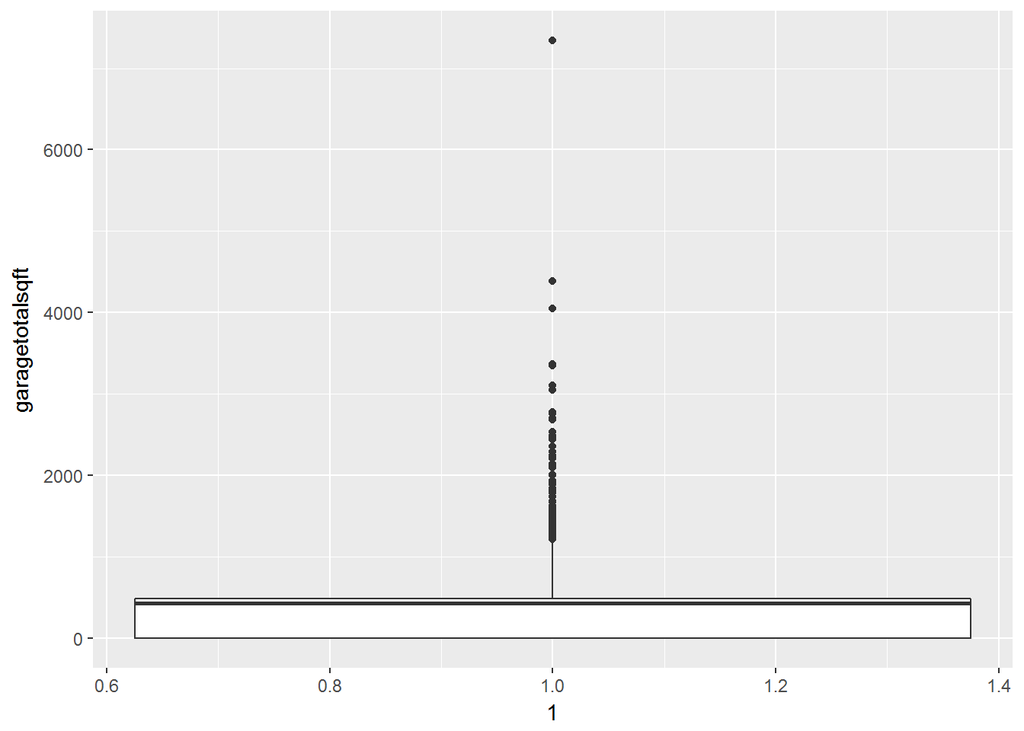

```r
ggplot(prop_train, aes(x = 1, y = garagetotalsqft)) +
  geom_boxplot()
```

```r
# Check to see that garagecarcnt and garagetotalsqft
# when one feature is present, the other should be there too
with(prop_train, which(is.na(garagecarcnt) != is.na(garagetotalsqft)))
```

```
## integer(0)
```

So just convert NA to zero

## regionidneighborhood, regionidcity, regionidzip, regionidcounty

```r
# Determine how granular each regionid contains
prop_train %>%
  summarize(ncounty = length(unique(regionidcounty)),
            nacounty = sum(is.na(regionidcounty)),
            ncity = length(unique(regionidcity)),
            nacity = sum(is.na(regionidcity)),
            nneighborhood = length(unique(regionidneighborhood)),
            naneighborhood = sum(is.na(regionidneighborhood)),
            nzip = length(unique(regionidzip)),
            nazip = sum(is.na(regionidzip)))
```

```
## # A tibble: 1 x 8
##   ncounty nacounty ncity nacity nneighborhood naneighborhood  nzip nazip
##     <int>    <int> <int>  <int>         <int>          <int> <int> <int>
## 1       4       17   178   1818           495          54205   389    52
```

location detail: coarse to fine county > city > zip > neighborhood

```r
table(prop_train$regionidcounty, prop_train$fips)
```

```
##
##        Los Angeles Orange Ventura
##   1286           0  24467       0
##   2061           0      0    7190
##   3101       58476      0       0
```

regionidcounty is redudant since fips holds the same information.

```r
prop_train$regionidzip %>% table(useNA = 'always') %>% .[. < 35]
```

```
## .
## 399675  95991  95995  95998  96002  96021  96034  96039  96119  96148
##     13     18     12     21      4     29      1      3     30     11
##  96207  96226  96323  96329  96434  96467  96500  96951  96973  96980
##     32      1     33      5     30      1      2     26     27     33
##  97037  97108  97111  97119  97316  97324  97331
##     32      6      1     17     26     16     20
```

**399675** is not a legit zip code.

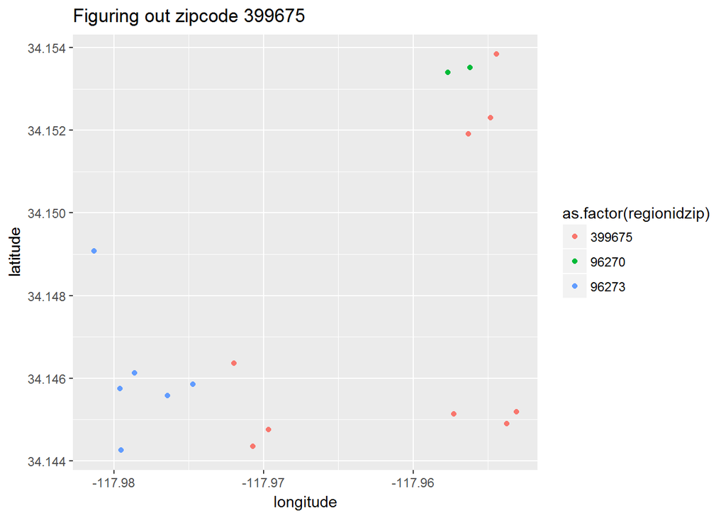

```r
# Determine the location where zip code 399675
tmp <- prop_train %>%
  filter(regionidzip == '399675') %>%
  summarize(long_min = min(longitude),
            long_max = max(longitude),
            lat_min = min(latitude),
            lat_max = max(latitude))


prop_train %>%
  filter(longitude > tmp$long_min,
         longitude < tmp$long_max,
         latitude > tmp$lat_min,
         latitude < tmp$lat_max) %>%
  ggplot(aes(x = longitude, y = latitude, color = as.factor(regionidzip))) +
  geom_point() +
  labs(title = "Figuring out zipcode 399675")
```

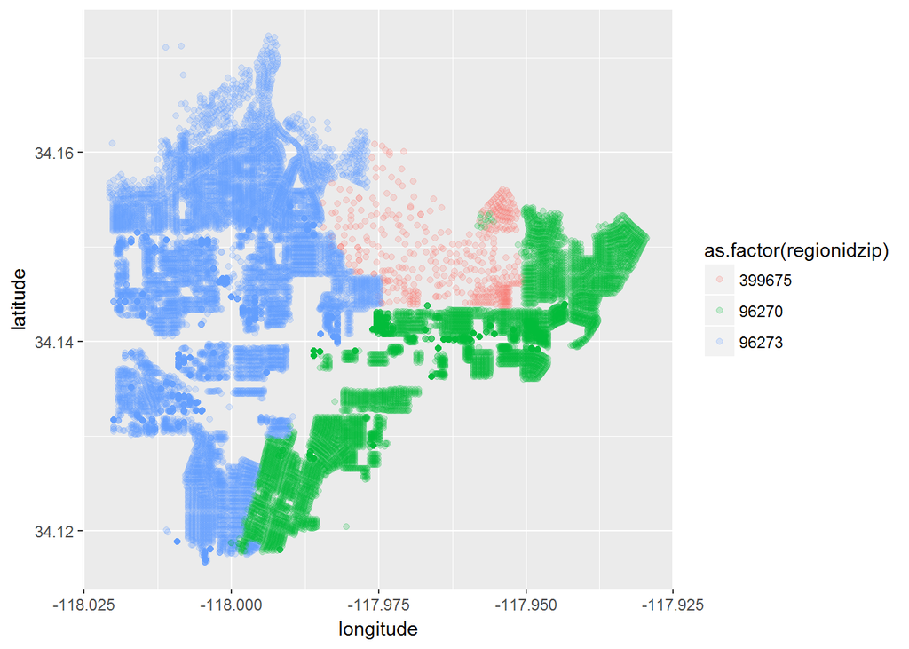

```r
###### This is on the whole dataset #######
prop_2016 %>%
  filter(regionidzip %in% c('399675', '96270', '96273')) %>%
  ggplot(aes(x = longitude, y = latitude, color = as.factor(regionidzip))) +
  geom_point(alpha = 0.2)
```

Yes it is possible that 399675 is not a legit zip code but it doesn’t look random so keep it as is.

## heatingorsystemtypeid

```r
prop_train$heatingorsystemtypeid %>% table(useNA = 'always')
```

```
## .
##       Baseboard         Central            Coal      Convection
##              13           38504               0               0
##        Electric      Forced air      Floor/Wall             Gas
##               0             968           16370               0
##     Geo Thermal         Gravity       Heat Pump       Hot Water
##               0               2               1               1
##            None           Other             Oil         Partial
##              76               2               0               0
##         Propane         Radiant           Steam           Solar
##               0              25               0             112
## Space/Suspended            Vent    Wood Burning             Yes
##               0               0               0            1069
##            Zone            <NA>
##               0           33007
```

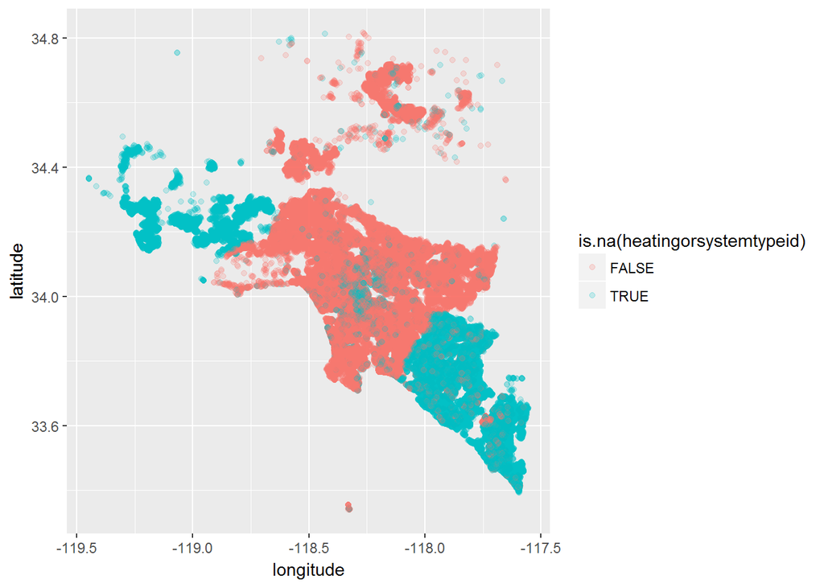

```r
ggplot(prop_train,
       aes(x = longitude, y = latitude, color = is.na(heatingorsystemtypeid))) +
  geom_point(alpha = 0.2)
```

It looks like missing is just none since it don’t look like it is random.

## propertyzoningdesc

```r
tmp <- prop_train %>%
  group_by(propertyzoningdesc) %>%
  summarise(n = n())

summary(tmp)
```

```
##  propertyzoningdesc       n
##  Length:1997        Min.   :    1.00
##  Class :character   1st Qu.:    1.00
##  Mode  :character   Median :    4.00
##                     Mean   :   45.14
##                     3rd Qu.:   14.00
##                     Max.   :31935.00
```

The distribution for this featuer is very unbalance and majority only has a few.

```r
## Counts of counts of the propertyzoningdesc
table(tmp$n)
```

```
##
##     1     2     3     4     5     6     7     8     9    10    11    12
##   572   236   152   101    85    75    66    37    41    36    27    29
##    13    14    15    16    17    18    19    20    21    22    23    24
##    23    21    21    23    24    25    12     5    14    11     8    10
##    25    26    27    28    29    30    31    32    33    34    35    36
##    10     7     8     6    10     5     9     6     2     7     8     5
##    37    38    39    40    41    42    43    44    45    46    47    48
##     5    10     4     3     6     7     6     3     2    13     5     3
##    49    50    51    52    53    54    55    56    57    58    59    60
##     1     2     3     2     3     4     1     4     2     3     2     2
##    61    62    63    64    65    66    67    68    69    70    71    72
##     3     3     2     2     4     1     2     5     2     2     2     4
##    73    74    76    77    78    79    81    82    83    84    86    87
##     1     1     3     3     1     1     3     2     2     2     1     2
```

[output cut: 16 more lines]

```r
# Determine the percentage of population if I aggregate the minor factors together
# k was selected out of random.
k = 100
tmp[tmp$n < k,] %>%
  summarise(nreduced = n(),
            fraction = sum(n)/nrow(prop_train)*100)
```

```
## # A tibble: 1 x 2
##   nreduced fraction
##      <int>    <dbl>
## 1     1896  22.1797
```

Factors that occur less than 100 in the training set is combined into the other category. This is to reduce the number of levels and to prevent overfitting due to limited samples in that level.

## lotsizesquarefeet

```r
prop_train$lotsizesquarefeet %>% summary()
```

```
##    Min. 1st Qu.  Median    Mean 3rd Qu.    Max.    NA's
##     167    5701    7200   29109   11679 6971010   10106
```

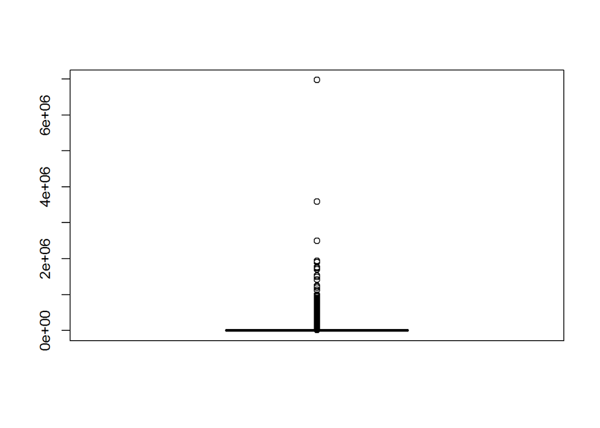

```r
prop_train$lotsizesquarefeet %>% boxplot()
```

Definitely a lot of outliers

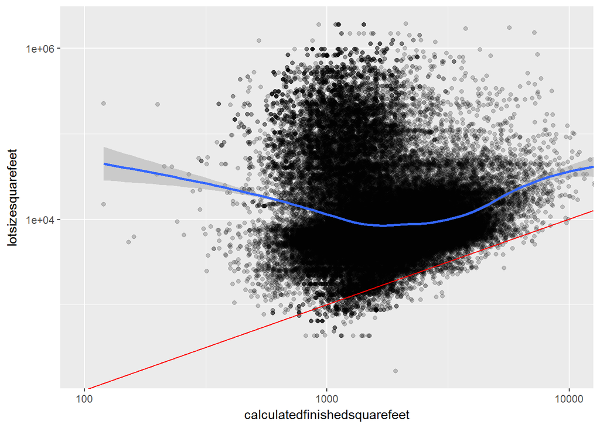

```r
## There are too many outliers for lotsizesquare feet.

prop_train %>%
  filter(lotsizesquarefeet < 2000000,
         calculatedfinishedsquarefeet > 100) %>%
  ggplot(aes(calculatedfinishedsquarefeet, lotsizesquarefeet)) +
  geom_point(alpha = 0.2) +
  geom_smooth() +
  geom_abline(slope = 1, color = "red") +
  scale_x_log10() +
  scale_y_log10() +
  coord_cartesian(xlim = c(100, 10000))
```

There doesn’t look like a linear relationship between calcualtedfinishedsquarefeet and lotsizesquarefeet.

## yearbuilt

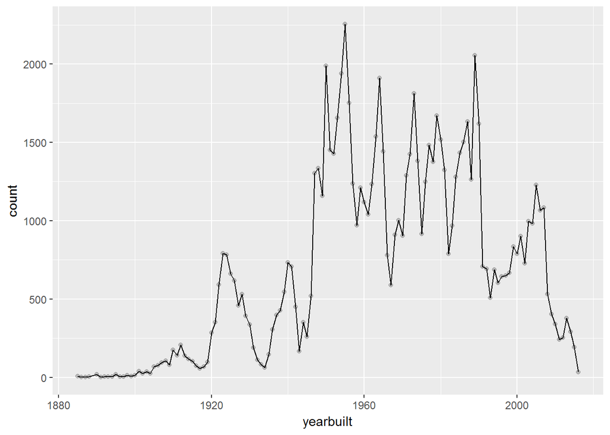

```r
prop_train %>%
  group_by(yearbuilt) %>%
  summarize(count = n()) %>%
  ggplot(aes(x = yearbuilt, y = count)) +
  geom_line() +
  geom_point(alpha = 0.2)
```

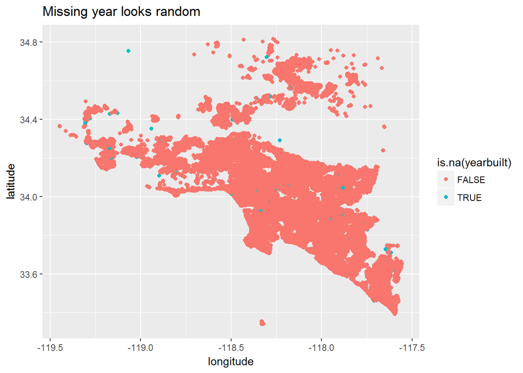

```r
ggplot(prop_train, aes(x= longitude, y = latitude, color = is.na(yearbuilt))) +
  geom_point() +
  labs(title = "Missing year looks random")
```

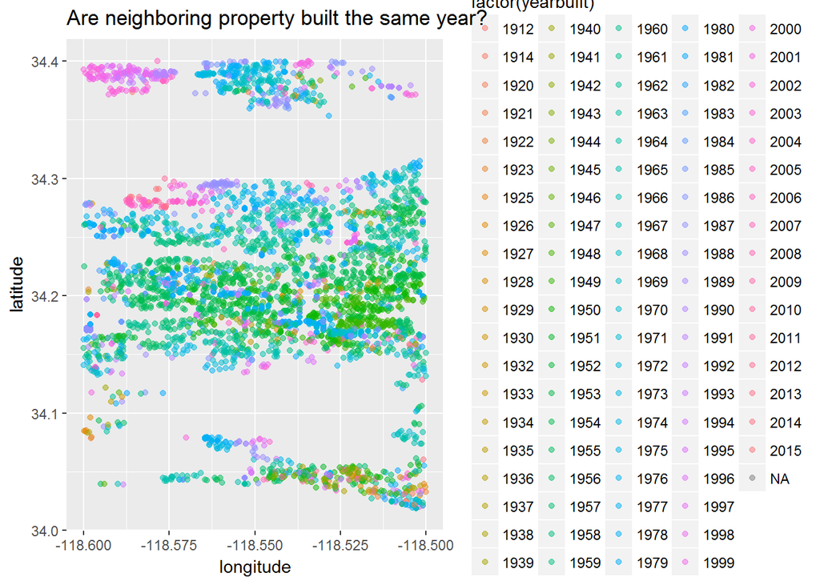

```r
## Looking closely at a random area on the map
prop_train %>%
  filter(longitude < -118.5,
         longitude > -118.6,
         latitude < 34.4,
         latitude > 34.0) %>%
  ggplot(aes(x= longitude, y = latitude, color = factor(yearbuilt))) +
  geom_point(alpha = 0.5) +
  labs(title = "Are neighboring property built the same year?")
```

It doesn’t look like there is a strong correlation between property built year with neighboring properties. Certain areas are true, but there are many that aren’t.

However, only a small proportion of properties are missing their year.

## censustractandblock, rawcensustractandblock

both of these features has the same definition in the data dictionary but censustractandblock is missing a few so it can be thrown out since information is redundant.

## structuretaxvaluedollarcnt

```r
prop_train$structuretaxvaluedollarcnt %>% summary()
```

```
##     Min.  1st Qu.   Median     Mean  3rd Qu.     Max.     NA's
##      100    86914   138912   190295   219876 15489086      302
```

```r
# check if there is a pattern like back to back NA
# which(is.na(prop_train$structuretaxvaluedollarcnt)) %>% diff()
# None
```

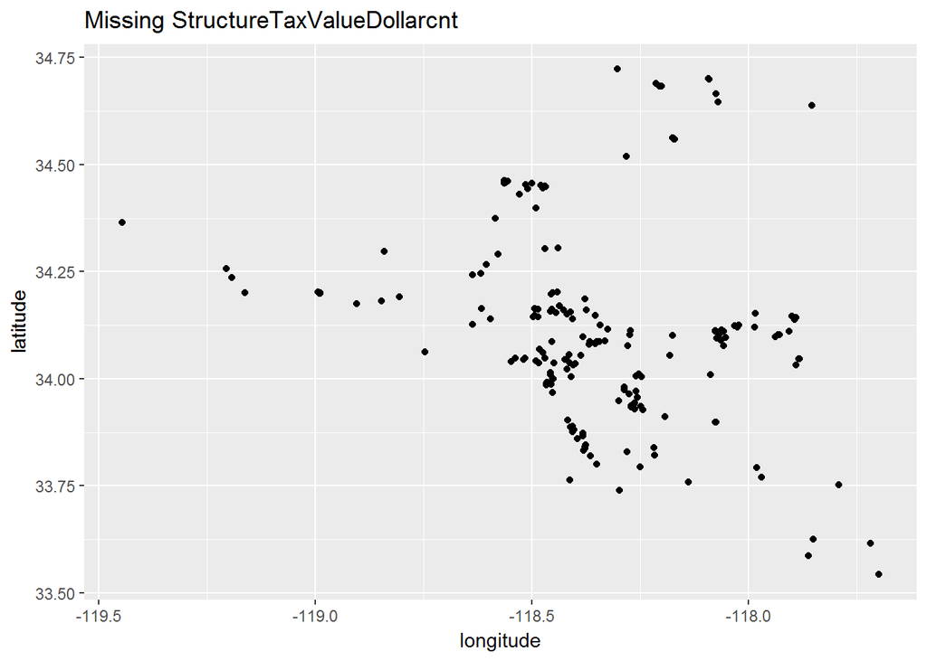

```r
# Check to see if it is location based
prop_train %>%
  filter(is.na(structuretaxvaluedollarcnt)) %>%
  ggplot(aes(x= longitude,
           y = latitude)) +
  geom_point() +
  labs(title = 'Missing StructureTaxValueDollarcnt')
```

The NA looks random.

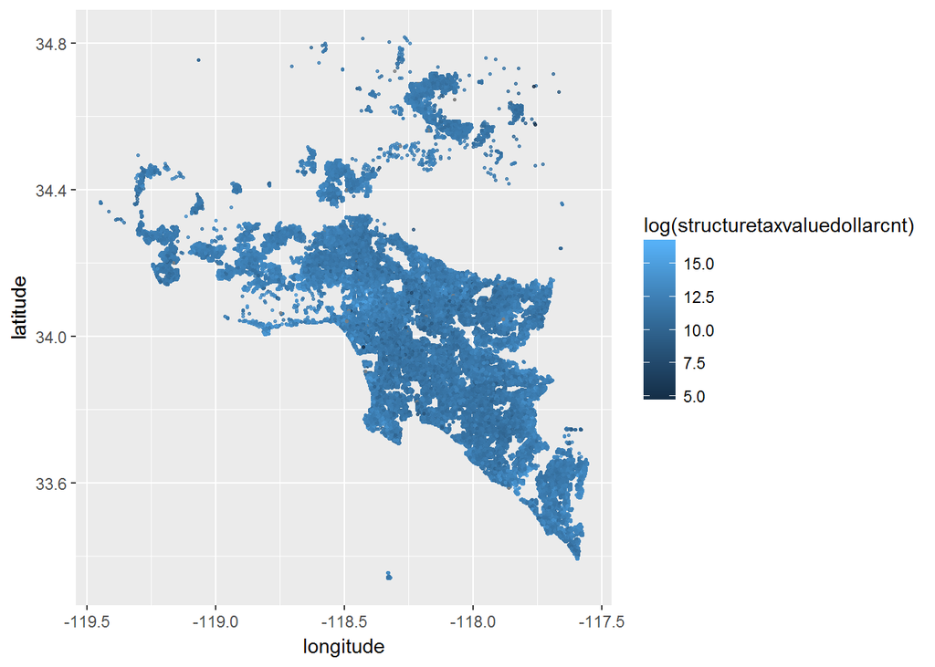

```r
ggplot(prop_train,
       aes(x = longitude,
           y = latitude,
           color = log(structuretaxvaluedollarcnt))) +
  geom_point(alpha = .8, size = 0.5)
```

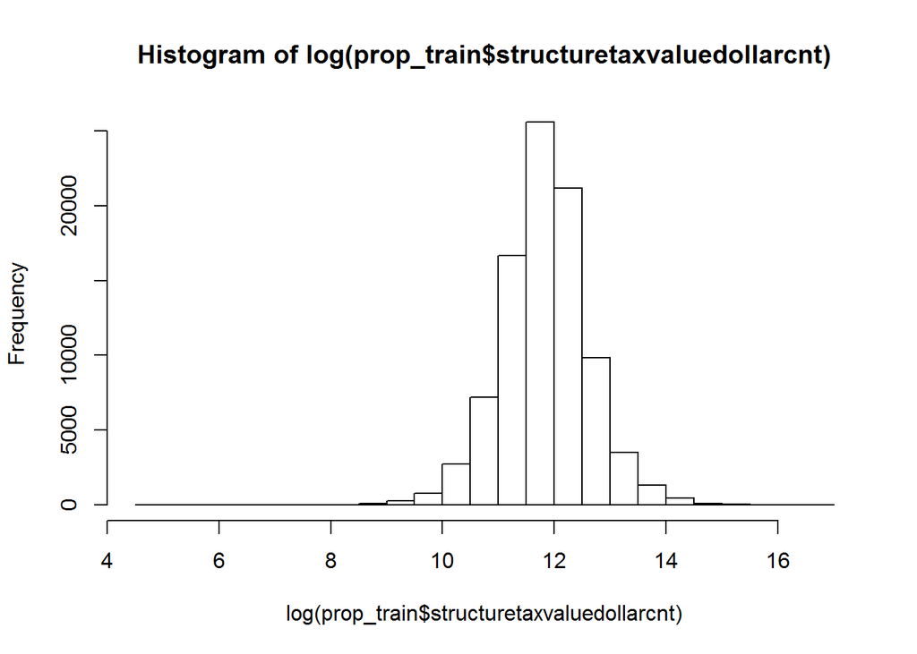

```r
hist(log(prop_train$structuretaxvaluedollarcnt))
```

## propertycountylandusecode

```r
prop_train$propertycountylandusecode %>%
  table() %>%
  prop.table() %>%
  `*`(100) %>%
  round(digits = 1) %>%
  sort()
```

```
## .
##    0  010 0102 0105 0109 010F 0110 0111 0114 012D 012E 0130 0131 01DD 0201
##  0.0  0.0  0.0  0.0  0.0  0.0  0.0  0.0  0.0  0.0  0.0  0.0  0.0  0.0  0.0
## 020G 020M 0210 030G 0401 040A 040V 070D 1011  105 1112 1116 1200 1222 1310
##  0.0  0.0  0.0  0.0  0.0  0.0  0.0  0.0  0.0  0.0  0.0  0.0  0.0  0.0  0.0
## 1321 1333  135 1410 1420 1421 1432 1720 1722 6050   73 0108 010G 010H 010M
##  0.0  0.0  0.0  0.0  0.0  0.0  0.0  0.0  0.0  0.0  0.0  0.1  0.1  0.1  0.1
## 0700 1117 1210   38   96 0103 010V 01HC 01DC 0104 1128 012C 0300 0400 1110
##  0.1  0.1  0.1  0.1  0.1  0.2  0.2  0.2  0.3  0.4  0.4  0.6  0.6  0.8  1.2
## 1129 010D 0200 010E    1 1111   34 0101 010C  122 0100
##  1.8  2.4  2.4  2.5  3.2  4.3  6.6  8.2 11.4 17.0 34.1
```

# Export

```r
# Renaming prop_2017 which is really the csv properties_2017.csv
prop_2017 <- prop_2016
rm(prop_2016)
save(prop_2017,sample_sub, sample_sub_dates, train_2016, train_2017, map_loc, file = 'data/raw_data.RData')
```